# Erbschaften in Wien: Einsichten aus Verlassenschaftsakten

27.02.2024

## Hintergrund

## Überblick

- Problem: Bessere Datenbasis zu Erbschaften erforderlich
- Vorschlag: Zusammenstellen und deskriptive Auswertung eines neuen Datensatzes zu Erbschaften in Wien
- Ansatz: Erschließung der Verlassenschaftsakten in Wiener Bezirksgerichten, die den Übergang des Eigentums von Erblasser:innen auf Erb:innen dokumentieren.

## Motivation I

Erbschaften sind von großer Bedeutung für zentrale ökonomische Prozesse. Das umfasst zum Beispiel:

- Arbeitsangebot
- Konsum- und Sparverhalten
- Öffentliche Finanzen
- Vermögensakkumulation und -verteilung
- Soziale Mobilität

## Motivation II

Aber: Empirische Evidenz zum Erben in Österreich und Wien stark limitiert.

- Seit Abschaffung der Erbschafts- und Vermögenssteuer (2008, 1993) keine Steuerdaten verfügbar
- Umfragen zu Erbschaften: Household Finance and Consumption Survey (alle 3 Jahre, retrospektive Fragen zu Erbschaften)
  - Umfragen bringen unterschiedliche Verzerrungen mit sich (v.a. beim Erben): bis zu 80 Prozent Unterschätzung des Erbvolumens (AT-Spzeifikum: Oberes Ende (Top 1%) nicht von Befragung erfasst (“missing rich problem”), große Unterschiede der Vermögensaggregate die durch VGR vs. HFCS)
  - Geringe Fallzahlen machen regional fokussierte Auswertung statistisch unzuverlässig

## Bisherige Erkenntnisse I

Daten zum Erben in Österreich und Wien, Stärken und Schwächen der bisherigen Evidenz

## Bisherige Erkenntnisse II

- Vermögensverteilung in Städten höher als in ländlichen Regionen
- mögliche Erklärungsansätze:
  - Hohe Meldedichte von sehr reichen und sehr armen Menschen
  - Relativ wenig Wohneigentumsverhältnisse
- Allerdings verringert öffentliches Vermögen die Vermögensungleichheit in Wien stark
- Relevanz von Erbschaften: deutliche Zunahme aufgrund von demografischen Wandel

## Bisherige Erkenntnisse III

- Nachlassdaten (Verwendung insbes. UK) erfassen üblicherweise nur das obere Ende der Verteilung, und weisen lediglich einen geschätzen Gesamtwert des Nachlasses aus (wenige Informationen über verstorbene Personen)
- Besonderheit der Nachlassdaten aus Verlassenschaftsverfahren in AT: Alle Verstorbenen erfasst, gesamtes Nachlassverfahren wird im Akt dokumentiert, gozio-Demographie der Verstorbenen erhoben, detaillierte Aufschlüsselung des Gesamtnachlasses nach Vermögenskomponenten
- Verwendung bisher für Geschichtswissenschaft

## Das Verlassenschaftsverfahren

## Verlassenschaften

- Österreichisches Erbrecht sieht vor, dass Vermögen von Erblasser:innen nicht automatisch in Eigentum der erbberechtigten Personen übergeht: Vermögen bekommt eine Rechtsperson (“Verlassenschaft”)
  - Verlassenschaftsverfahren zur Übertragung von Eigentum
  - Durchgeführt von Notar:innen (Gerichtskommissär:innen)
- Im Verlassenschaftsverfahren wird das Vermögen der Verstorbenen Person ermittelt
- Die Verfahrensschritte und Erkenntnisse werden in einem Akt dokumentiert und im zuständigen Bezirksgericht archiviert
- Akten unterliegen strenger Geheimhaltung. Es gibt eine Ausnahme für wissenschaftliche Zwecke - §219(4) ZPO

## Prozedere nach dem Tod

- Erstellung einer Sterbeurkunde welche dem zuständigen Bezirksgericht überstellt wird
- Zuordnung des bzw. der zuständigen Notar:in und Erstellung der Todesfallaufnahme:
  - Zusammentragen wesentlicher Informationen zur verstorbenen Person und zu den gesetzlichen Erb:innen und Personen, die durch Testamente/Vermächtnisse begünstigt werden
  - Einholen von Infos zu Aktiva/Passiva
  - Entscheidung über Einleitung eines Verlassenschaftsverfahrens
  - Weitere Vorkehrungen

## Verfahrensarten

- Verfahrensarten ohne Abhandlung:
  - Unterbleibung gem. § 153 AußStrG: max. Aktivavermögen < 4.000 Euro bzw seit 16.8.2015 < 5.000 Euro
  - Überlassung an Zahlungs statt: Überlassung der Aktiva an Gläubiger:innen
  - Verlassenschaftsinsolvenz
- Verfahrensarten mit Abhandlung:
  - Negative Erbantrittserklärung: Entschlagung der Erbschaft
  - Unbedingte Erbantrittserklärung: persönliche Haftung bei allen Gläubiger:innen
  - Bedingte Erbantrittserklärung: Begrenzte Haftung durch den geerbten Betrag der Aktiva

## Methodik

## Datengrundlage

- Todesfallaufnahme (Formular)
- Je nach Verfahren
  - Vermögenserklärung
  - Inventar
  - Beschluss/Einantwortungsbeschluss
- Außerdem:
  - Rechnungen
  - Testamente

## Stichprobe

- Teilstichprobe 1:
  - Geschichtetes Zufallsverfahren in Bezirksgerichten Innere Stadt, Döbling und Donaustadt (Politische Bezirke: 1, 3, 4, 5, 6, 11, 18, 19, 22)
  - Oversampling von komplexen Fällen (5% der Akten mit den meisten Verfahrensschritten je Bezirk)
  - Überproportionale Ziehung war erfolgreich (höheres Durchschnittsvermögen beobachtbar)
- Teilstichprobe 2:
  - Reines Zufallsverfahren im Bezirksgericht Meidling
- Beide Teilstichproben ergeben eine Gesamtstichprobe von 13% der Population

## Gewichtete Verfahrensarten

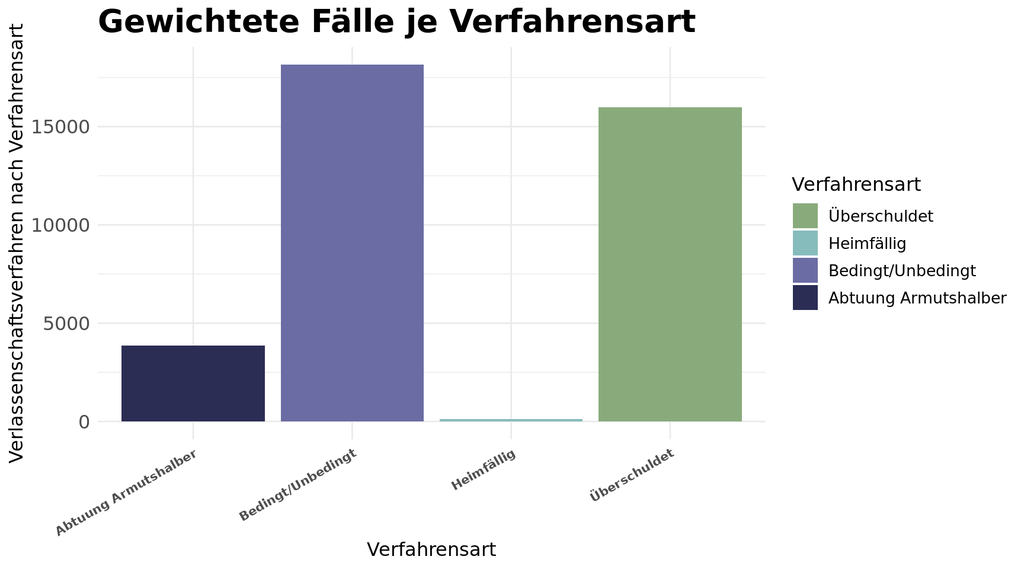

## Definition des Nachlassvermögens

- Positive Aktiva minus Passiva des bzw. der Erblasser:in:
  - Individuell zurechenbares Vermögen (bei gemeinsamen Vermögen Hälftanteil)
  - Inklusive Begräbniskosten/Versicherungen
  - Exklusive Notarkosten, Verlassenschaftskurator, nicht-nachlasszugehöriges Vernmögen
  - Korrigierete Immobilienwerte: Einfaches Schätzmodell zum Verhältnis des 3-fachen Einheitswerts und Marktwertes (Gutachten oder Kaufpreise)
  - Inklusive nicht-nachlasszugehörige Versicherungen
  - Inklusive nicht vollständig dokumentierter Schulden

## Immobilien I

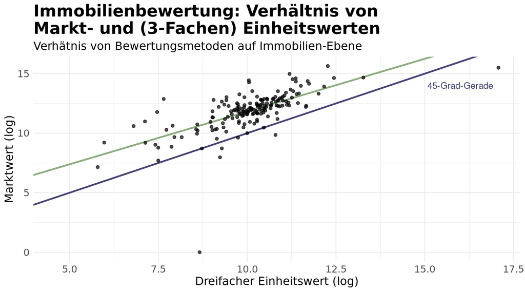

##Immobilien II

- Relation zwischen den Bewertungsmethoden dreifacher Einheitswert und Marktwert liegt bei rund 1:6,2
- Relation zwischen einfachem Einheitswert und Marktwert dementsprechend bei ca. 1:18,5
- Differenz zwischen den Methoden hat in den letzten Jahren und Jahrzehnten zugenommen
- Unterstreicht die Relevanz alle Immobilien die mit dreifachem Einheitswert bewertet wurden zu korrigieren

## Verteilung von Nachlassvermögen in Wien

## Sozio-Demographie der Verstorbenen I

Letzter Wohnort der Erblasser:innen

| Postleitzahl | Fallzahl |
| --- | --- |
| 1010 | 973 |
| 1030 | 4.812 |
| 1040 | 1.607 |
| 1050 | 2.660 |
| 1060 | 1.637 |
| 1110 | 4.743 |
| 1120 | 5.558 |
| 1180 | 2.259 |
| 1190 | 4.923 |
| 1220 | 7.637 |
| Andere | 251 |
| Andere AT | 382 |
| Ausland | 665 |

Anmerkung: Die Tabelle bildet die gewichtete Anzahl an Verlassenschaftsverfahren für verschiedene Wiener Bezirke ab. Außerdem gibt die Kategorie "Andere" Personen mit unbekannten oder ohne letzten Wohnort an. "Andere AT" und "Ausland" listen Verstorbene auf, die ihren letzten Wohnort in einem anderen Österreichischen Bezirk oder im Ausland hatten. Quelle: Eigene Berechnung unter Verwendung von Populationsgewichten.

## Sozio-Demographie der Verstorbenen II

Sozio-Demographie der Erblasser:innen

| Beschreibung | Anzahl | Anteil |
| --- | --- | --- |
| Anzahl Frauen | 20.183 | 52,96 |
| Anzahl Männer | 17.923 | 47,03 |
| Durchschnitt Alter | 77 | N. Def |
| Durchschnitt Alter Frauen | 81 | N. Def |
| Durchschnitt Alter Männer | 73 | N. Def |
| Anzahl AT Staatsangehörigkeit | 34.888 | 91,55 |
| Anzahl Nicht-AT Staatsangehörigkeit | 3.219 | 8,45 |

Anmerkung: In der Tabelle sind verschiedene gewichtete Charakteristika durch die absolute sowie relative Anzahl abgebildet. Prozentuelle Anteile in Bezug auf Alters-Kennziffern sind nicht definiert (N. Def). Quelle: Eigene Berechnung unter Verwendung von Populationsgewichten.

## Verteilung der Nachlassvermögen I

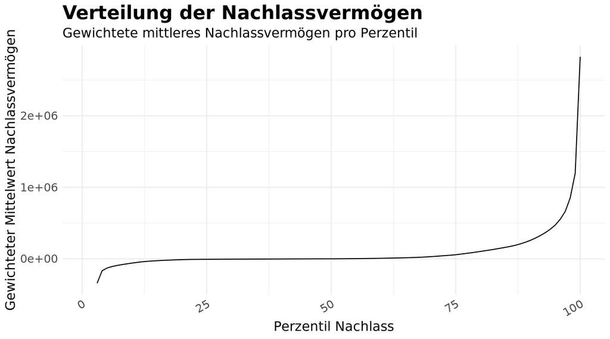

## Verteilung der Nachlassvermögen II

Gini Index nach Todesjahr

| Todesjahr | Gini Index |
| --- | --- |
| 2014 | 1,194 |
| 2015 | 1,232 |
| 2016 | 1,500 |
| 2017 | 1,210 |
| 2018 | 1,062 |
| 2019 | 1,038 |

Anmerkung: Die Tabelle illustriert die Gini Indizes der Nachlassvermögen für alle Jahre der Stichprobe. Die Zuordnung von Fälle zu Jahren basiert auf Sterbejahren. Quelle: Eigene Berechnung unter Verwendung von Populationsgewichten.

## Verteilung der Nachlassvermögen III

Ungleichheitsmaße - Verteilung der Nachlassvermögen

| Indikator | Anteil |
| --- | --- |
| Oberste 1% | 38,80 |
| Oberste 5% | 72,15 |
| Oberste 10% | 90,33 |
| Unterste 50 % | -16,57 |

Anmerkung: Die Tabelle zeigt ausgewählte Indikatoren der Verlassenschaftsverteilung. Die Werte sind jeweils Anteile der reichsten 1%, 5%, 10% und ärmsten 50% am Gesamtvermögen. Der negative Wert bei den unteren 50% ergibt sich aus der Überschuldung vieler Verstorbener in diesem Bereich der Vermögensverteilung. Quelle: Eigene Berechnung unter Verwendung von Populationsgewichten.

## Verteilung der Nachlassvermögen IV

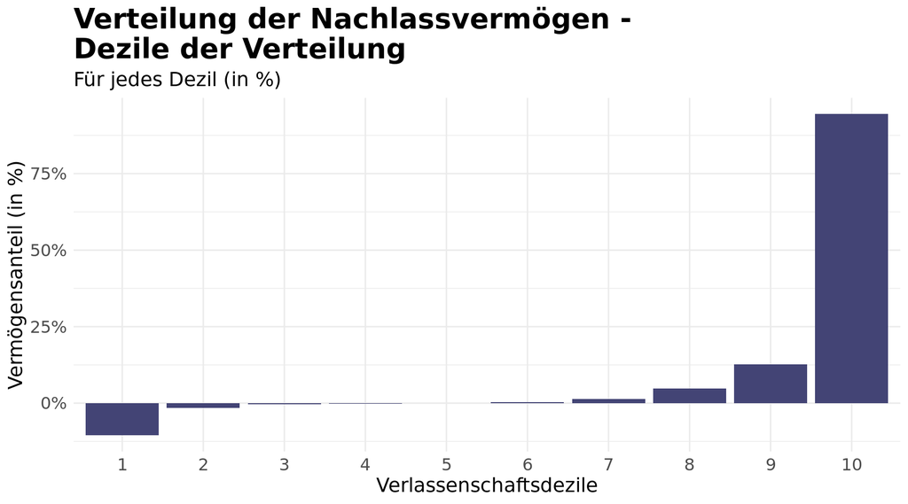

## Partizipationsraten

Partizipationsraten

| Art | Gewichtete Summe | Anteil Sample | Anteil HFCS 2017 in Wien |
| --- | --- | --- | --- |
| Eigentum der Immobilie | 7.295 | 19,14 | 29,20 |
| Personenkraftwagen | 5.958 | 15,64 | 57,70 |
| Aktien oder Anleihen | 6.549 | 17,19 | 17,40 |
| Bausparvertrag | 6.600 | 17,32 | 36,90 |
| Sparbuch | 11.297 | 29,65 |  |
| Bankkonto | 32.291 | 84,74 | 99,70 |
| Bargeld | 8.905 | 23,37 |  |
| Wertgegenstände | 8.003 | 21,00 | 27,70 |
| Bankschulden | 3.761 | 9,87 |  |
| Beteiligung an Unternehmen | 545 | 1,43 | 4,43 |

aAggregat für Sparbuch + Bankkonto  
Anmerkung: Die Tabelle gibt die Partizipation an verschiedenen Vermögensarten an. Die erste Spalte bezieht sich auf die Anzahl an Verlassenschaften, in denen die jeweilige Vermögensart (je Zeile) gehalten wurde. Die zweite Spalte zeigt den Anteil der Verlassenschaften mit Partizipation an einer Vermögenskomponente an allen Verlassenschaften. Die dritte Spalte zeigt die Partizipation auf Basis des HFCS (2017) in Prozent. Quellen: Eigene Berechnung unter Verwendung von Populationsgewichten und HFCS 2017.

## Geschlechterspezifische Unterschiede I

Vermögen im Nachlass nach Geschlecht

| Geschlecht | Anzahl Fälle | Mittelwert | Median | Gini | Aggregiertes Vermögen pro Geschlecht | Aggregiertes Vermögen aller Geschlechter |
| --- | --- | --- | --- | --- | --- | --- |
| M | 17.923 | 124.180,25 | 1.196,63 | 1,16 | 2.226 Mio. | 4.173 Mio. |
| W | 20.183 | 96.490,18 | 0,00 | 1,21 | 1.947 Mio. | 4.173 Mio. |

Anmerkung: Die Tabelle illustriert verschiedene Kennzahlen und unterscheidet dabei zwischen Männern und Frauen. Die letzte Spalte zeigt das aggregierte Vermögen der gewichteten Gesamtmenge aller beobachteten Personen (ohne zwischen den Geschlechtern zu unterscheiden). Quelle: Eigene Berechnung unter Verwendung von Populationsgewichten.

## Geschlechterspezifische Unterschiede II

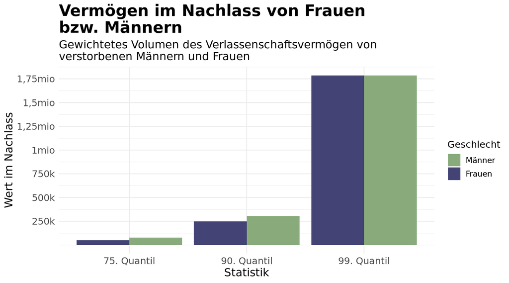

## Von Nachlassvermögen zu deren Erb:innen

## Verteilung der Erb:innen I

Anzahl Erbantrittserklärungen gesamt

| Art | Anzahl | Anteil |
| --- | --- | --- |
| An Zahlung statt | 21.094 | 37,42 |
| Bedingt | 13.731 | 24,36 |
| Entschlagung | 2.216 | 3,93 |
| Legat | 96 | 0,17 |
| Sonstiges | 419 | 0,74 |
| Unbedingt | 18.822 | 33,39 |
| Summe | 56.378 | 100,00 |

Anmerkung: Die Tabelle zeigt die Anzahl der Erbantrittserklärungen von Erb:innen und die Anteile aller Erbantrittserklärungen relativ zur Gesamtsumme. Quelle: Eigene Berechnung unter Verwendung von Populationsgewichten.

## Verteilung der Erb:innen II

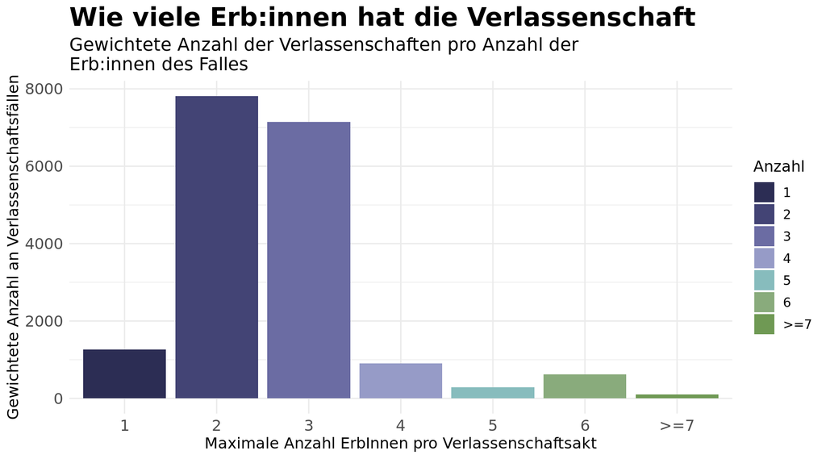

## Verteilung der Erb:innen III

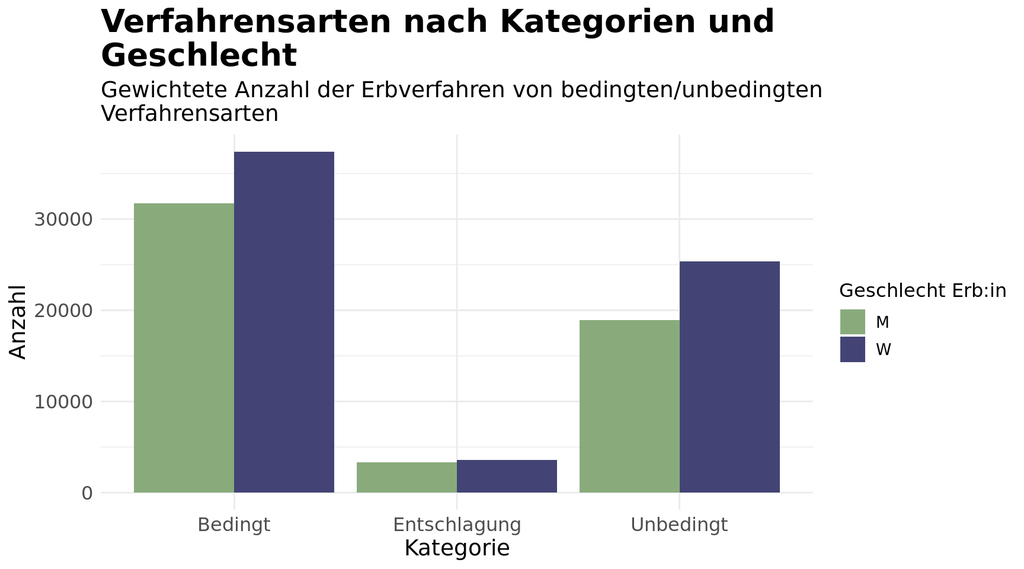

## Verteilung der Erb:innen IV

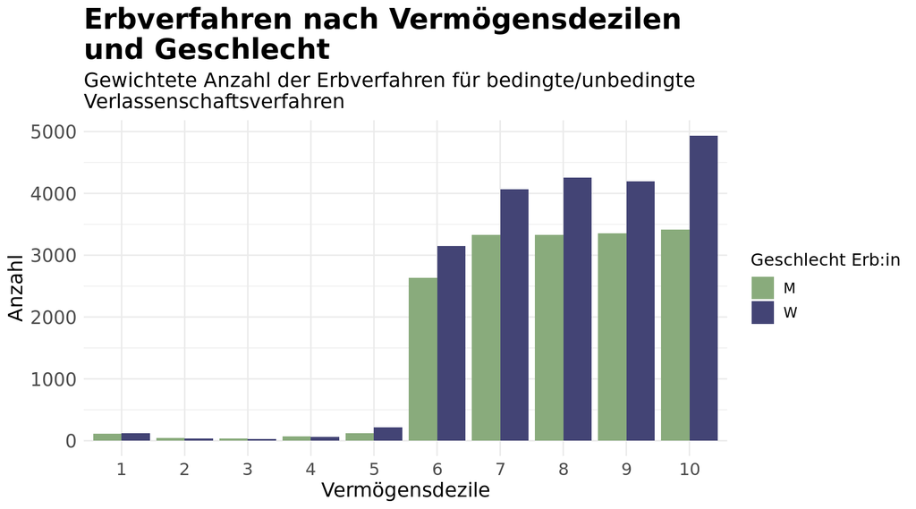

## Zusammenfassung und Diskussion

## Zusammenfassung und Diskussion

- Relation Marktwerte zu dreifachen Einheitswerten: 1:6,2
- Relation Marktwerte zu einfachen Einheitswerten: 1:18,5
- Starke Konzentration der Nachlassvermögen auf die obersten Quantile:
  - Oberste 1%: 39% des Nachlassvermögens
  - Oberste 5%: 72% des Nachlassvermögens
  - Oberste 10%: 90% des Nachlassvermögens
- Median Verlassenschaftsvermögen: 0 Euro
- Untere Hälfte der Nachlassverteilung vererbt nichts oder überlässt Schulden
- Gini-Koeffizienten zwischen 1,038 und 1,5
- Stärkere Konzentration von Nachlassvermögen und Vermächtnissen als es bisher der Fall war

## Appendix

## Weitere Kennzahlen I

Gewichtetes Nettovermögen pro Vingtil, pro Perzentil des oberstens Deziles (Top 10%), sowie bei den größten 0,5%, 0,1% der Verlassenschaften

| Vintile | Gewichtetes Nettovermögen (Vintile) | Oberstes Dezil | Gewichtetes Nettovermögen (Perzentile) |
| --- | --- | --- | --- |
| 1. Vingtil | -230,223.52 | 90. Perzentil | 286,449.9 |
| 2. Vingtil | -70,847.82 | 91. Perzentil | 324,745.8 |
| 3. Vingtil | -30,830.28 | 92. Perzentil | 365,634.7 |
| 4. Vingtil | -14,311.55 | 93. Perzentil | 407,292.0 |
| 5. Vingtil | -7,533.22 | 94. Perzentil | 470,532.2 |
| 6. Vingtil | -5,359.81 | 95. Perzentil | 540,310.3 |
| 7. Vingtil | -3,895.78 | 96. Perzentil | 651,162.3 |
| 8. Vingtil | -2,516.98 | 97. Perzentil | 795,644.5 |
| 9. Vingtil | -1,031.92 | 98. Perzentil | 1,112,681.6 |
| 10. Vingtil | -9.26 | 99. Perzentil | 1,682,678.1 |
| 11. Vingtil | 1,952.21 | 100. Perzentil | 5,679,974.6 |
| 12. Vingtil | 6,305.66 | Top 0,5 | 8,987,970.6 |
| 13. Vingtil | 13,504.48 | Top 0,1 | 19,220,226.5 |
| 14. Vingtil | 26,225.09 |  |  |
| 15. Vingtil | 51,815.18 |  |  |
| 16. Vingtil | 93,838.51 |  |  |
| 17. Vingtil | 147,511.02 |  |  |
| 18. Vingtil | 234,633.22 |  |  |
| 19. Vingtil | 421,830.38 |  |  |
| 20. Vingtil | 1,889,472.16 |  |  |

Anmerkung: Die Tabelle zeigt die Vingtile des gewichteten Verlassenschaftsvermögens. Außerdem werden die Top 0,5% und Top 0,1% der Nachlassverteilung abgebildet. Negative Werte bedeuten Nachlassschulden. Quelle: Eigene Berechnung unter Verwendung von Populationsgewichten.

## Weitere Kennzahlen II

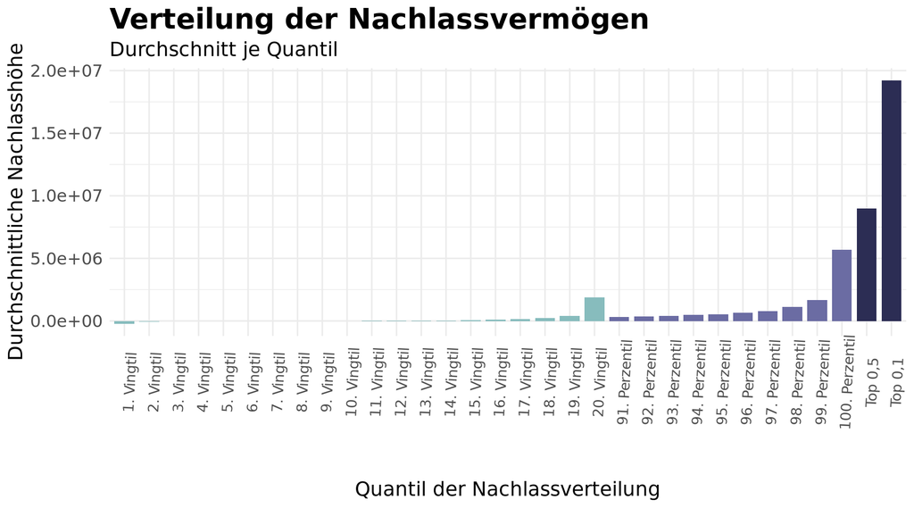

## Zusammenhang Marktwert und Einheitswerte von Immobilien

Modell-Summary von verschiedenen Regressionen

|  | Modell 1 | Modell 2 | Modell 3 | Modell 4 |
| --- | --- | --- | --- | --- |
| Achsenabschnitt | 2,958*** | 11,669*** | 12,444*** | 11,777*** |
|  | (0,748) | (1,355) | (0,915) | (0,613) |
| Dreifacher Einheitswert (log) | 0,886*** | -0,052 | -0,053 | 0,027 |
|  | (0,074) | (0,054) | (0,058) | (0,051) |
| # Beobachtungen | 179 | 266 | 266 | 267 |
| R2 | 0,448 | 0,016 | 0,218 | 0,098 |

Anmerkung: Die Tabelle illustriert die Koeffizienten der verschiedenen Modelle. Außerdem werden die Anzahl der Beobachtungen und die R-Squared-Werte angegeben. Drei Sterne bei den einzelnen Werten bedeuten p-Werte von < 0,01. Quelle: Eigene Berechnung.

## Populationsgewichte

Mögliche Gewichtungskriterien Nachlassvermögen

| Koeffizient | Nationalität | Zivilstand | Alter |
| --- | --- | --- | --- |
| Achsenabschnitt | -2,16 | 0,7 | -2,68 |
|  | (0,78) | (0,47) | (6,12) |
| Geschlecht Weiblich | 1,56 |  |  |
|  | (3,64) |  |  |
| R2 | 0,0098 | 0,0219 | 0,0225 |

Anmerkung: Die Tabelle zeigt mögliche Gewichtungskriterien des Nachlassvermögens. Die erste Spalte zeigt die Arten der verschiedenen Koeffizienten an. Die folgenden Spalten repräsentieren die sozioökonomischen Charakteristika. Standardfehler stehen in den Klammern. Quelle: Eigene Berechnung.

## Einfluss der Hochrechnungen I

Vergleich der Anteil der Altersgruppen für gewichtete bzw. hochgerechnete Gesamtmenge

| Altersgruppe | Anteil an der gewichteten Gesamtmenge | Anteil an der gewichteten und hochgerechneten Gesamtmenge | Differenz zwischen den beiden Anteilen |
| --- | --- | --- | --- |
| 0-10 | 1,16 | 0,58 | -0,58 |
| 10-20 | 0,26 | 0,06 | -0,20 |
| 20-30 | 0,72 | 0,45 | -0,27 |
| 30-40 | 1,26 | 0,81 | -0,45 |
| 40-50 | 2,80 | 1,97 | -0,83 |
| 50-60 | 7,95 | 6,60 | -1,35 |
| 60-70 | 14,02 | 13,24 | -0,78 |
| 70-80 | 23,80 | 25,83 | 2,03 |
| 80-90 | 25,55 | 28,91 | 3,36 |
| 90-100 | 20,79 | 20,26 | -0,53 |
| 100-110 | 1,05 | 0,87 | -0,19 |

Anmerkung: Die Tabelle zeigt die Anteile verschiedener Altersgruppen an verschiedenen untersuchten Gesamtmengen (gewichtet vs. gewichtet und hochgerechnet. Die letzte Spalte illustriert die Differenz zwischen den beiden vorher angezeigten Anteilen. Quelle: Eigene Berechnung unter Verwendung der Populationsgewichte und der Hochrechnung.

## Einfluss der Hochrechnungen II

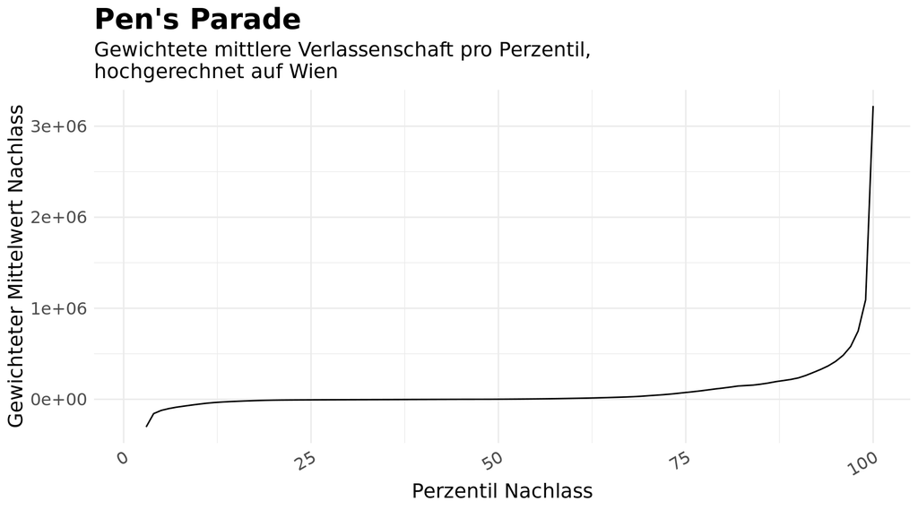

## Einfluss der Hochrechnungen III

Indikatoren Hochrechnung Stadtgebiet

| Indikator | Wert |
| --- | --- |
| Oberste 1% | 49,385 |
| Oberste 5% | 73,927 |
| Oberste 10% | 88,440 |
| Unterste 50 % | -16,566 |

Anmerkung: Die Tabelle zeigt ausgewählte hochgerechnete Indikatoren der Verlassenschaftsverteilung. Die Werte sind jeweils Anteile der reichsten 1%, 5%, 10% und ärmsten 50% am Gesamtvermögen. Der negative Wert bei den unteren 50% ergibt sich aus der Überschuldung vieler Verstorbener in diesem Bereich der Vermögensverteilung. ´ Quelle: Eigene Berechnung unter Verwendung von Populationsgewichten und Hochrechnung.